# Course Project 1 (Statistic Analysis of Activity Monitoring Data)

Eduardo V K

7/31/2020

# Reading the dataset

First, a “read data” script is added to obtain the file that will be read.

```r
library(dplyr)
  if(!file.exists("./data")){

    dir.create("./data")

    unzip(zipfile ="./data/repdata_data_activity.zip",exdir = "./data")
    # The script automatically looks for and validates if the selected directory for the file is in the computer. If it is not, it's added, along with the file

  }

path1 <- file.path("./data", "activity.csv")
act <- read.csv(path1)
```

This script makes sure there’s a “data” directory path and, if not, it creates one, while unzipping the already downloaded file. Make sure to check that the file and the data are both in the same directory path.

# Obtaining the quantitative data of the number of steps taken each day, and presenting it as a histogram

First off, a snapshot and a summary of the obtained data structure is done.

```r
head(act)
```

```
##   steps       date interval
## 1    NA 2012-10-01        0
## 2    NA 2012-10-01        5
## 3    NA 2012-10-01       10
## 4    NA 2012-10-01       15
## 5    NA 2012-10-01       20
## 6    NA 2012-10-01       25
```

```r
summary(act)
```

```
##      steps                date          interval
##  Min.   :  0.00   2012-10-01:  288   Min.   :   0.0
##  1st Qu.:  0.00   2012-10-02:  288   1st Qu.: 588.8
##  Median :  0.00   2012-10-03:  288   Median :1177.5
##  Mean   : 37.38   2012-10-04:  288   Mean   :1177.5
##  3rd Qu.: 12.00   2012-10-05:  288   3rd Qu.:1766.2
##  Max.   :806.00   2012-10-06:  288   Max.   :2355.0
##  NA's   :2304     (Other)   :15840
```

We’ll check if the “date” section of the data frame is in an actual POSTIX date format

```r
class(act$date)
```

```
## [1] "factor"
```

We’ll soon realize this is not the case, so we’ll rectify that.

```r
act$date <- as.POSIXct(act$date)
```

We’ll now rectify that the class of “date” is in a POSIX date format.

```r
class(act$date)
```

```
## [1] "POSIXct" "POSIXt"
```

The number of steps taken per day can now be inicialized.

First, a data frame that uses the dates as a grouping method will be created using the “date” and “steps” subsets. The gouping will also be done here

```r
actDatSte2 <- with(act, aggregate(steps, by = list(date), FUN = sum, na.rm = TRUE))

actDatSte2 <- actDatSte2 %>% rename(steps = x, date = Group.1)
```

Finally, the histogram is obtained, giving the reader the required information without considering NAs

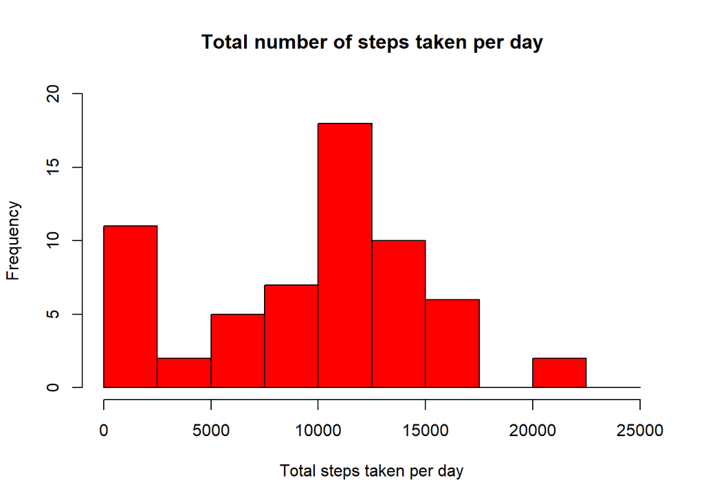

```r
hist(actDatSte2$steps, main = "Total number of steps taken per day", xlab = "Total steps taken per day", col = "red", ylim = c(0,20), breaks = seq(0,25000, by=2500))
```

# Obtention of mean and median of daily steps

Once the filtered data set is obtained we just need to use the mean and median for the “steps” dataset

```r
mean(actDatSte2$steps)
```

```
## [1] 9354.23
```

Same goes for the median.

```r
median(actDatSte2$steps)
```

```
## [1] 10395
```

# Obtention of the 5 minute interval containing the maximum number of steps (on average)

```r
actInt <- with(act, aggregate(steps, by = list(interval), FUN = mean, na.rm = TRUE))
actInt <- actInt %>% rename(steps = x, interval = Group.1)
actInt[actInt$steps==max(actInt$steps),][1]
```

```
##     interval
## 104      835
```

The plot of the average number of steps per five minute interval will be done in order to illustrate the aforementioned result.

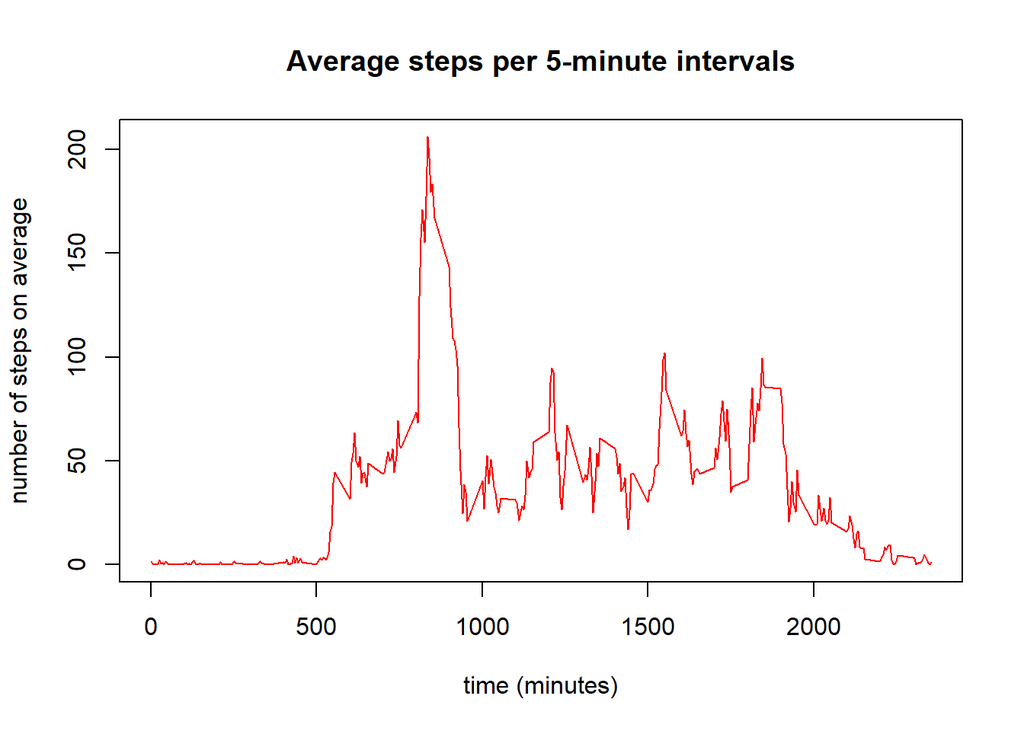

```r
plot(actInt$interval,actInt$steps, type = "l",col = "red", xlab = "time (minutes)", ylab = "number of steps on average", main = "Average steps per 5-minute intervals")
```

# Strategy used to imput missing data

```r
avgStep <- actInt$steps[match(act$interval,actInt$interval)]
actImp <- transform(act, steps = ifelse(is.na(act$steps), yes = avgStep, no = act$steps))
```

# Corrected histogram present in previous steps

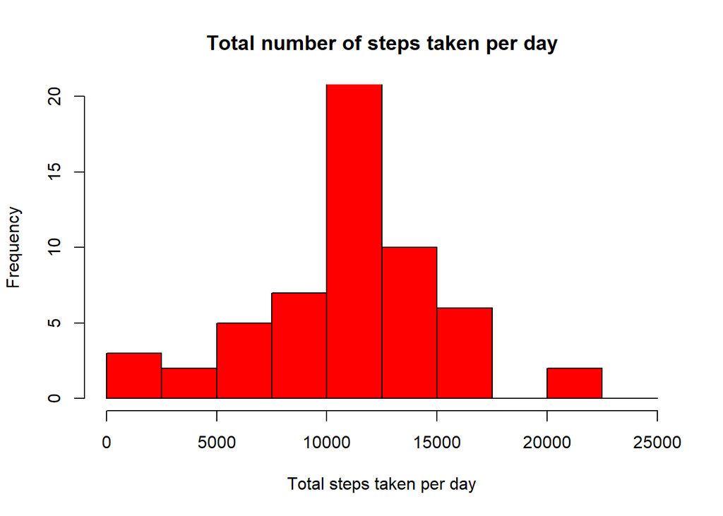

```r
actDatSte3 <- with(actImp, aggregate(steps, by = list(date), FUN = sum, na.rm = TRUE))

actDatSte3 <- actDatSte3 %>% rename(steps = x, date = Group.1)

hist(actDatSte3$steps,main = "Total number of steps taken per day", xlab = "Total steps taken per day", col = "red", ylim = c(0,20), breaks = seq(0,25000, by=2500))
```

# Plotting the average number of steps taken per 5-minute intervals on weekdays and weekends

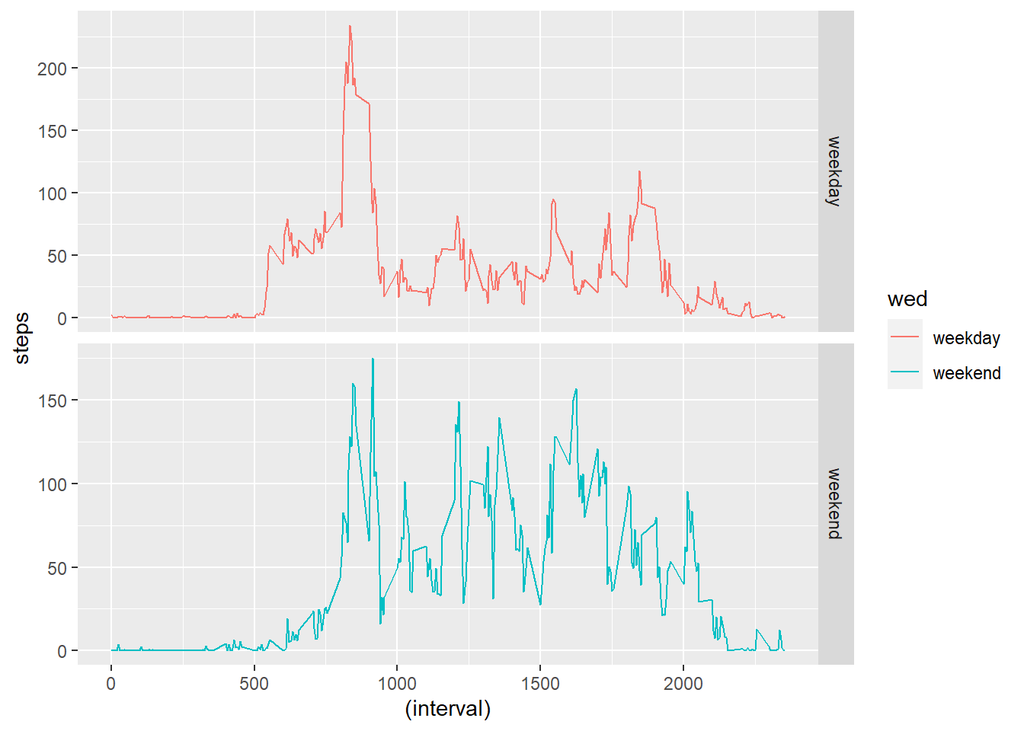

```r
library(ggplot2)
act2 <- act

act2$wday <- weekdays(act$date)
act2$na.rm <- NULL

act2$wed <- (act2$wday == "Saturday" | act2$wday == "Sunday")
act2 <- act2 %>% mutate(wed = factor(wed, labels = c("weekday","weekend")))
actI2 <- aggregate(steps~interval + wed, act2, mean, na.rm = TRUE)

ggplot(actI2, aes(x = (interval), y = steps, color = wed)) +
  geom_line() +  facet_grid(wed~.,scales="free")
```